# Проект: Анализ развлекательного приложения Procrastinate Pro+

**Цель исследования**  
Выявить причины убытков компании через анализ привлеченных пользователей и помочь компании выйти в плюс.

**План**

1. Импортировать данные и провести обработку(чистка от пропусков, преобразование типов столбцов)
2. Провести исследовательский анализ данных:
   - Определить, откуда приходят пользователи и какими устройствами они пользуются;
   - Посчитать сколько стоит привлечение пользователей из различных рекламных каналов;
   - Вычислить сколько денег приносит каждый клиент;
   - Определить, когда расходы на привлечение клиента окупаются и какие факторы мешают привлечению клиентов.
3. Вывод и рекоммендации

```python
import pandas as pd
import numpy as np
from datetime import datetime, timedelta
from matplotlib import pyplot as plt
```

## Подготовка данных

Загрузите данные о визитах, заказах и рекламных расходах из CSV-файлов в переменные.

**Пути к файлам**

- визиты: `/datasets/visits_info_short.csv`. [Скачать датасет](https://code.s3.yandex.net/datasets/visits_info_short.csv);
- заказы: `/datasets/orders_info_short.csv`. [Скачать датасет](https://code.s3.yandex.net/datasets/orders_info_short.csv);
- расходы: `/datasets/costs_info_short.csv`. [Скачать датасет](https://code.s3.yandex.net/datasets/costs_info_short.csv).

Изучите данные и выполните предобработку. Есть ли в данных пропуски и дубликаты? Убедитесь, что типы данных во всех колонках соответствуют сохранённым в них значениям. Обратите внимание на столбцы с датой и временем.

### Загрузка данных, проверка на пропуски и дубликаты

```python
visits, orders, costs = (
    pd.read_csv('/datasets/visits_info_short.csv'),
    pd.read_csv('/datasets/orders_info_short.csv'),
    pd.read_csv('/datasets/costs_info_short.csv')
)

data_tables = {'visits': visits, 'orders': orders, 'costs': costs}

def data_preparation_func(data):
    for name, i in data.items():
        print(f"\033[1mИнформация по таблице {name}:\033[0m")
        i.info()
        duplicates = i.duplicated().sum()
        print(f"\033[1mКоличество дубликатов в таблице {name}:\033[1m {duplicates}\n")

data_preparation_func(data_tables)
```

```
Информация по таблице visits:
<class 'pandas.core.frame.DataFrame'>
RangeIndex: 309901 entries, 0 to 309900
Data columns (total 6 columns):
 #   Column         Non-Null Count   Dtype
---  ------         --------------   -----
 0   User Id        309901 non-null  int64
 1   Region         309901 non-null  object
 2   Device         309901 non-null  object
 3   Channel        309901 non-null  object
 4   Session Start  309901 non-null  object
 5   Session End    309901 non-null  object
dtypes: int64(1), object(5)
memory usage: 14.2+ MB
Количество дубликатов в таблице visits: 0

Информация по таблице orders:
<class 'pandas.core.frame.DataFrame'>
RangeIndex: 40212 entries, 0 to 40211
Data columns (total 3 columns):
 #   Column    Non-Null Count  Dtype
---  ------    --------------  -----
 0   User Id   40212 non-null  int64
 1   Event Dt  40212 non-null  object
 2   Revenue   40212 non-null  float64
dtypes: float64(1), int64(1), object(1)
memory usage: 942.6+ KB
Количество дубликатов в таблице orders: 0

Информация по таблице costs:
<class 'pandas.core.frame.DataFrame'>
RangeIndex: 1800 entries, 0 to 1799
Data columns (total 3 columns):
 #   Column   Non-Null Count  Dtype
---  ------   --------------  -----
 0   dt       1800 non-null   object
 1   Channel  1800 non-null   object
 2   costs    1800 non-null   float64
dtypes: float64(1), object(2)
memory usage: 42.3+ KB
Количество дубликатов в таблице costs: 0
```

### Описание данных

**Таблица visits содержит следующие данные:**

- *User Id* — уникальный идентификатор пользователя, тип данных: int64, тип данных неверный для даты, нужно заменить на object
- *Region* — страна пользователя, тип данных: object
- *Device* — тип устройства пользователя, тип данных: object
- *Channel* — идентификатор источника перехода, тип данных: object
- *Session Start* — дата и время начала сессии, тип данных: object, тип данных неверный для даты, нужно заменить на datetime64[ns]
- *Session End* — дата и время окончания сессии, тип данных: object, тип данных неверный для даты, нужно заменить на datetime64[ns]

**Таблица orders содержит следующие данные:**

- *User Id* — уникальный идентификатор пользователя, тип данных: int64, тип данных неверный для даты, нужно заменить на object
- *Event Dt* — дата и время покупки, тип данных: object, тип данных неверный для даты, нужно заменить на datetime64[ns]
- *Revenue* — сумма заказа, тип данных: float64.

*Все таблицы с данными не содержат пропусков и дубликатов*

### Преобразуем типы данных в столбцах

Столбцы на замену  
**visits:**

- *User Id* - с int64 на object, так как это идентификатор пользователя
- *Session Start* — с object нужно заменить на datetime64[ns], так как это дата
- *Session End* — с object нужно заменить на datetime64[ns], так как это дата

**orders:**

- *User Id* - с int64 на object, так как это идентификатор пользователя
- *Event Dt* — с object нужно заменить на datetime64[ns], так как это дата

**costs:**

- *dt* — с object нужно заменить на datetime64[ns], так как это дата

```python
visits['User Id'] = visits['User Id'].astype('object')
visits['Session Start'] = pd.to_datetime(visits['Session Start'])
visits['Session End'] = pd.to_datetime(visits['Session End'])

orders['User Id'] = orders['User Id'].astype('object')
orders['Event Dt'] = pd.to_datetime(orders['Event Dt'])

costs['dt'] = pd.to_datetime(costs['dt']).dt.date
```

```python
print(visits.dtypes)
print(orders.dtypes)
print(costs.dtypes)
```

```
User Id                  object
Region                   object
Device                   object
Channel                  object
Session Start    datetime64[ns]
Session End      datetime64[ns]
dtype: object
User Id             object
Event Dt    datetime64[ns]
Revenue            float64
dtype: object
dt          object
Channel     object
costs      float64
dtype: object
```

### Переименование колонок

```python
visits.columns = visits.columns.str.lower().str.replace(' ', '_')
orders.columns = orders.columns.str.lower().str.replace(' ', '_')
costs.columns = costs.columns.str.lower().str.replace(' ', '_')
print(visits.columns)
print(orders.columns)
print(costs.columns)
```

```
Index(['user_id', 'region', 'device', 'channel', 'session_start',
       'session_end'],
      dtype='object')
Index(['user_id', 'event_dt', 'revenue'], dtype='object')
Index(['dt', 'channel', 'costs'], dtype='object')
```

### Мини итог

- Были импортированы данные для анализа, таблицы: visits, orders и costs;
- Проведена обработка(чистка от пропусков, проверка на дубликаты, преобразование типов данных столбцов):  
  *User Id* — с int64 на object, так как это идентификатор пользователя  
  *Session Start* — с object нужно заменить на datetime64[ns], так как это дата  
  *Session End* — с object нужно заменить на datetime64[ns], так как это дата  
  *User Id* — с int64 на object, так как это идентификатор пользователя  
  *Event Dt* — с object нужно заменить на datetime64[ns], так как это дата  
  *dt* — с object нужно заменить на datetime64[ns], так как это дата
- Переименованны колонок по стилю snake case

## Функции для расчёта и анализа LTV, ROI, удержания и конверсии.

### Задайте функции для расчёта и анализа LTV, ROI, удержания и конверсии.

Разрешается использовать функции, с которыми вы познакомились в теоретических уроках.

Это функции для вычисления значений метрик:

- `get_profiles()` — для создания профилей пользователей,
- `get_retention()` — для подсчёта Retention Rate,
- `get_conversion()` — для подсчёта конверсии,
- `get_ltv()` — для подсчёта LTV.

А также функции для построения графиков:

- `filter_data()` — для сглаживания данных,
- `plot_retention()` — для построения графика Retention Rate,
- `plot_conversion()` — для построения графика конверсии,
- `plot_ltv_roi` — для визуализации LTV и ROI.

```python
# функция для создания профилей пользователей

def get_profiles(sessions, orders, events, ad_costs, event_names=[]):
    profiles = (
        sessions.sort_values(by=['user_id', 'session_start'])
        .groupby('user_id')
        .agg(
            {
                'session_start': 'first',
                'channel': 'first',
                'device': 'first',
                'region': 'first',
            }
        )
        .rename(columns={'session_start': 'first_ts'})
        .reset_index()
    )
    profiles['dt'] = profiles['first_ts'].dt.date
    profiles['month'] = profiles['first_ts'].astype('datetime64[M]')
    profiles['payer'] = profiles['user_id'].isin(orders['user_id'].unique())


    new_users = (
        profiles.groupby(['dt', 'channel'])
        .agg({'user_id': 'nunique'})
        .rename(columns={'user_id': 'unique_users'})
        .reset_index()
    )
    ad_costs = ad_costs.merge(new_users, on=['dt', 'channel'], how='left')
    ad_costs['acquisition_cost'] = ad_costs['costs'] / ad_costs['unique_users']
    profiles = profiles.merge(
        ad_costs[['dt', 'channel', 'acquisition_cost']],
        on=['dt', 'channel'],
        how='left',
    )
    profiles['acquisition_cost'] = profiles['acquisition_cost'].fillna(0)

    return profiles
```

```python
# функция для подсчёта Retention Rate

def get_retention(
    profiles,
    sessions,
    observation_date,
    horizon_days,
    dimensions=[],
    ignore_horizon=False,
):

    # добавляем столбец payer в передаваемый dimensions список
    dimensions = ['payer'] + dimensions

    # исключаем пользователей, не «доживших» до горизонта анализа
    last_suitable_acquisition_date = observation_date
    if not ignore_horizon:
        last_suitable_acquisition_date = observation_date - timedelta(
            days=horizon_days - 1
        )
    result_raw = profiles.query('dt <= @last_suitable_acquisition_date')

    # собираем «сырые» данные для расчёта удержания
    result_raw = result_raw.merge(
        sessions[['user_id', 'session_start']], on='user_id', how='left'
    )
    result_raw['lifetime'] = (
        result_raw['session_start'] - result_raw['first_ts']
    ).dt.days

    # функция для группировки таблицы по желаемым признакам
    def group_by_dimensions(df, dims, horizon_days):
        result = df.pivot_table(
            index=dims, columns='lifetime', values='user_id', aggfunc='nunique'
        )
        cohort_sizes = (
            df.groupby(dims)
            .agg({'user_id': 'nunique'})
            .rename(columns={'user_id': 'cohort_size'})
        )
        result = cohort_sizes.merge(result, on=dims, how='left').fillna(0)
        result = result.div(result['cohort_size'], axis=0)
        result = result[['cohort_size'] + list(range(horizon_days))]
        result['cohort_size'] = cohort_sizes
        return result

    # получаем таблицу удержания
    result_grouped = group_by_dimensions(result_raw, dimensions, horizon_days)

    # получаем таблицу динамики удержания
    result_in_time = group_by_dimensions(
        result_raw, dimensions + ['dt'], horizon_days
    )

    # возвращаем обе таблицы и сырые данные
    return result_raw, result_grouped, result_in_time
```

```python
# функция для подсчёта конверсии

def get_conversion(
    profiles,
    purchases,
    observation_date,
    horizon_days,
    dimensions=[],
    ignore_horizon=False,
):

    # исключаем пользователей, не «доживших» до горизонта анализа
    last_suitable_acquisition_date = observation_date
    if not ignore_horizon:
        last_suitable_acquisition_date = observation_date - timedelta(
            days=horizon_days - 1
        )
    result_raw = profiles.query('dt <= @last_suitable_acquisition_date')

    # определяем дату и время первой покупки для каждого пользователя
    first_purchases = (
        purchases.sort_values(by=['user_id', 'event_dt'])
        .groupby('user_id')
        .agg({'event_dt': 'first'})
        .reset_index()
    )

    # добавляем данные о покупках в профили
    result_raw = result_raw.merge(
        first_purchases[['user_id', 'event_dt']], on='user_id', how='left'
    )

    # рассчитываем лайфтайм для каждой покупки
    result_raw['lifetime'] = (
        result_raw['event_dt'] - result_raw['first_ts']
    ).dt.days

    # группируем по cohort, если в dimensions ничего нет
    if len(dimensions) == 0:
        result_raw['cohort'] = 'All users'
        dimensions = dimensions + ['cohort']

    # функция для группировки таблицы по желаемым признакам
    def group_by_dimensions(df, dims, horizon_days):
        result = df.pivot_table(
            index=dims, columns='lifetime', values='user_id', aggfunc='nunique'
        )
        result = result.fillna(0).cumsum(axis=1)
        cohort_sizes = (
            df.groupby(dims)
            .agg({'user_id': 'nunique'})
            .rename(columns={'user_id': 'cohort_size'})
        )
        result = cohort_sizes.merge(result, on=dims, how='left').fillna(0)
        # делим каждую «ячейку» в строке на размер когорты
        # и получаем conversion rate
        result = result.div(result['cohort_size'], axis=0)
        result = result[['cohort_size'] + list(range(horizon_days))]
        result['cohort_size'] = cohort_sizes
        return result

    # получаем таблицу конверсии
    result_grouped = group_by_dimensions(result_raw, dimensions, horizon_days)

    # для таблицы динамики конверсии убираем 'cohort' из dimensions
    if 'cohort' in dimensions:
        dimensions = []

    # получаем таблицу динамики конверсии
    result_in_time = group_by_dimensions(
        result_raw, dimensions + ['dt'], horizon_days
    )

    # возвращаем обе таблицы и сырые данные
    return result_raw, result_grouped, result_in_time
```

```python
# функция для подсчёта LTV

def get_ltv(
    profiles,
    purchases,
    observation_date,
    horizon_days,
    dimensions=[],
    ignore_horizon=False,
):

    last_suitable_acquisition_date = observation_date
    if not ignore_horizon:
        last_suitable_acquisition_date = observation_date - timedelta(
            days=horizon_days - 1
        )
    result_raw = profiles.query('dt <= @last_suitable_acquisition_date')
    result_raw = result_raw.merge(
        purchases[['user_id', 'event_dt', 'revenue']], on='user_id', how='left'
    )
    result_raw['lifetime'] = (
        result_raw['event_dt'] - result_raw['first_ts']
    ).dt.days

    if len(dimensions) == 0:
        result_raw['cohort'] = 'All users'
        dimensions = dimensions + ['cohort']

    def group_by_dimensions(df, dims, horizon_days):
        result = df.pivot_table(
            index=dims, columns='lifetime', values='revenue', aggfunc='sum'
        )
        result = result.fillna(0).cumsum(axis=1)
        cohort_sizes = (
            df.groupby(dims)
            .agg({'user_id': 'nunique'})
            .rename(columns={'user_id': 'cohort_size'})
        )
        result = cohort_sizes.merge(result, on=dims, how='left').fillna(0)
        result = result.div(result['cohort_size'], axis=0)
        result = result[['cohort_size'] + list(range(horizon_days))]
        result['cohort_size'] = cohort_sizes
        cac = df[['user_id', 'acquisition_cost'] + dims].drop_duplicates()
        cac = (
            cac.groupby(dims)
            .agg({'acquisition_cost': 'mean'})
            .rename(columns={'acquisition_cost': 'cac'})
        )
        roi = result.div(cac['cac'], axis=0)
        roi = roi[~roi['cohort_size'].isin([np.inf])]
        roi['cohort_size'] = cohort_sizes
        roi['cac'] = cac['cac']
        roi = roi[['cohort_size', 'cac'] + list(range(horizon_days))]
        return result, roi

    result_grouped, roi_grouped = group_by_dimensions(
        result_raw, dimensions, horizon_days
    )
    if 'cohort' in dimensions:
        dimensions = []
    result_in_time, roi_in_time = group_by_dimensions(
        result_raw, dimensions + ['dt'], horizon_days
    )

    return (
        result_raw,  # сырые данные
        result_grouped,  # таблица LTV
        result_in_time,  # таблица динамики LTV
        roi_grouped,  # таблица ROI
        roi_in_time,  # таблица динамики ROI
    )
```

```python
# функция для сглаживания данных

def filter_data(df, window):
    for column in df.columns.values:
        df[column] = df[column].rolling(window).mean()
    return df
```

```python
# функция для построения графика Retention Rate

def plot_retention(retention, retention_history, horizon, window=7):

    # задаём размер сетки для графиков
    plt.figure(figsize=(15, 10))

    # исключаем размеры когорт и удержание первого дня
    retention = retention.drop(columns=['cohort_size', 0])
    # в таблице динамики оставляем только нужный лайфтайм
    retention_history = retention_history.drop(columns=['cohort_size'])[
        [horizon - 1]
    ]

    # если в индексах таблицы удержания только payer,
    # добавляем второй признак — cohort
    if retention.index.nlevels == 1:
        retention['cohort'] = 'All users'
        retention = retention.reset_index().set_index(['cohort', 'payer'])

    # в таблице графиков — два столбца и две строки, четыре ячейки
    # в первой строим кривые удержания платящих пользователей
    ax1 = plt.subplot(2, 2, 1)
    retention.query('payer == True').droplevel('payer').T.plot(
        grid=True, ax=ax1
    )
    plt.legend()
    plt.xlabel('Лайфтайм')
    plt.title('Удержание платящих пользователей')

    # во второй ячейке строим кривые удержания неплатящих
    # вертикальная ось — от графика из первой ячейки
    ax2 = plt.subplot(2, 2, 2, sharey=ax1)
    retention.query('payer == False').droplevel('payer').T.plot(
        grid=True, ax=ax2
    )
    plt.legend()
    plt.xlabel('Лайфтайм')
    plt.title('Удержание неплатящих пользователей')

    # в третьей ячейке — динамика удержания платящих
    ax3 = plt.subplot(2, 2, 3)
    # получаем названия столбцов для сводной таблицы
    columns = [
        name
        for name in retention_history.index.names
        if name not in ['dt', 'payer']
    ]
    # фильтруем данные и строим график
    filtered_data = retention_history.query('payer == True').pivot_table(
        index='dt', columns=columns, values=horizon - 1, aggfunc='mean'
    )
    filter_data(filtered_data, window).plot(grid=True, ax=ax3)
    plt.xlabel('Дата привлечения')
    plt.title(
        'Динамика удержания платящих пользователей на {}-й день'.format(
            horizon
        )
    )

    # в чётвертой ячейке — динамика удержания неплатящих
    ax4 = plt.subplot(2, 2, 4, sharey=ax3)
    # фильтруем данные и строим график
    filtered_data = retention_history.query('payer == False').pivot_table(
        index='dt', columns=columns, values=horizon - 1, aggfunc='mean'
    )
    filter_data(filtered_data, window).plot(grid=True, ax=ax4)
    plt.xlabel('Дата привлечения')
    plt.title(
        'Динамика удержания неплатящих пользователей на {}-й день'.format(
            horizon
        )
    )
    return filtered_data.head(30)
    plt.tight_layout()
    plt.show()
# функция для визуализации конверсии
```

```python
# функция для построения графика конверсии

def plot_conversion(conversion, conversion_history, horizon, window=7):

    # задаём размер сетки для графиков
    plt.figure(figsize=(15, 5))

    # исключаем размеры когорт
    conversion = conversion.drop(columns=['cohort_size'])
    # в таблице динамики оставляем только нужный лайфтайм
    conversion_history = conversion_history.drop(columns=['cohort_size'])[
        [horizon - 1]
    ]

    # первый график — кривые конверсии
    ax1 = plt.subplot(1, 2, 1)
    conversion.T.plot(grid=True, ax=ax1)
    plt.legend()
    plt.xlabel('Лайфтайм')
    plt.title('Конверсия пользователей')

    # второй график — динамика конверсии
    ax2 = plt.subplot(1, 2, 2, sharey=ax1)
    columns = [
        # столбцами сводной таблицы станут все столбцы индекса, кроме даты
        name for name in conversion_history.index.names if name not in ['dt']
    ]
    filtered_data = conversion_history.pivot_table(
        index='dt', columns=columns, values=horizon - 1, aggfunc='mean'
    )
    filter_data(filtered_data, window).plot(grid=True, ax=ax2)
    plt.xlabel('Дата привлечения')
    plt.title('Динамика конверсии пользователей на {}-й день'.format(horizon))

    plt.tight_layout()
    plt.show()
```

```python
# функция для визуализации LTV и ROI

def plot_ltv_roi(ltv, ltv_history, roi, roi_history, horizon, window=7):

    plt.figure(figsize=(20, 10))

    ltv = ltv.drop(columns=['cohort_size'])
    ltv_history = ltv_history.drop(columns=['cohort_size'])[[horizon - 1]]
    cac_history = roi_history[['cac']]
    roi = roi.drop(columns=['cohort_size', 'cac'])
    roi_history = roi_history.drop(columns=['cohort_size', 'cac'])[
        [horizon - 1]
    ]

    # первый график — кривые ltv
    ax1 = plt.subplot(2, 3, 1)
    ltv.T.plot(grid=True, ax=ax1)
    plt.legend()
    plt.xlabel('Лайфтайм')
    plt.title('LTV')

    # второй график — динамика ltv
    ax2 = plt.subplot(2, 3, 2, sharey=ax1)
    columns = [name for name in ltv_history.index.names if name not in ['dt']]
    filtered_data = ltv_history.pivot_table(
        index='dt', columns=columns, values=horizon - 1, aggfunc='mean'
    )
    filter_data(filtered_data, window).plot(grid=True, ax=ax2)
    plt.xlabel('Дата привлечения')
    plt.title('Динамика LTV пользователей на {}-й день'.format(horizon))

    # третий график — динамика cac
    ax3 = plt.subplot(2, 3, 3, sharey=ax1)
    columns = [name for name in cac_history.index.names if name not in ['dt']]
    filtered_data = cac_history.pivot_table(
        index='dt', columns=columns, values='cac', aggfunc='mean'
    )
    filter_data(filtered_data, window).plot(grid=True, ax=ax3)
    plt.xlabel('Дата привлечения')
    plt.title('Динамика стоимости привлечения пользователей')

    # четвёртый график — кривые roi
    ax4 = plt.subplot(2, 3, 4)
    roi.T.plot(grid=True, ax=ax4)
    plt.axhline(y=1, color='red', linestyle='--', label='Уровень окупаемости')
    plt.legend()
    plt.xlabel('Лайфтайм')
    plt.title('ROI')

    # пятый график — динамика roi
    ax5 = plt.subplot(2, 3, 5, sharey=ax4)
    columns = [name for name in roi_history.index.names if name not in ['dt']]
    filtered_data = roi_history.pivot_table(
        index='dt', columns=columns, values=horizon - 1, aggfunc='mean'
    )
    filter_data(filtered_data, window).plot(grid=True, ax=ax5)
    plt.axhline(y=1, color='red', linestyle='--', label='Уровень окупаемости')
    plt.xlabel('Дата привлечения')
    plt.title('Динамика ROI пользователей на {}-й день'.format(horizon))

    plt.tight_layout()
    plt.show()
```

### Мини итог

Введены функции вычисления значений метрик:

- `get_profiles()` — для создания профилей пользователей,
- `get_retention()` — для подсчёта Retention Rate,
- `get_conversion()` — для подсчёта конверсии,
- `get_ltv()` — для подсчёта LTV.

А также функции для построения графиков:

- `filter_data()` — для сглаживания данных,
- `plot_retention()` — для построения графика Retention Rate,
- `plot_conversion()` — для построения графика конверсии,
- `plot_ltv_roi` — для визуализации LTV и ROI.

## Исследовательский анализ данных

- Составьте профили пользователей. Определите минимальную и максимальную даты привлечения пользователей.
- Выясните, из каких стран пользователи приходят в приложение и на какую страну приходится больше всего платящих пользователей. Постройте таблицу, отражающую количество пользователей и долю платящих из каждой страны.
- Узнайте, какими устройствами пользуются клиенты и какие устройства предпочитают платящие пользователи. Постройте таблицу, отражающую количество пользователей и долю платящих для каждого устройства.
- Изучите рекламные источники привлечения и определите каналы, из которых пришло больше всего платящих пользователей. Постройте таблицу, отражающую количество пользователей и долю платящих для каждого канала привлечения.

После каждого пункта сформулируйте выводы.

### Профили пользователей

```python
# получаем профили пользователей
profiles = get_profiles(visits, orders, None, costs)
print(profiles.head(5))
```

```
    user_id            first_ts     channel  device         region  \
0    599326 2019-05-07 20:58:57    FaceBoom     Mac  United States
1   4919697 2019-07-09 12:46:07    FaceBoom  iPhone  United States
2   6085896 2019-10-01 09:58:33     organic  iPhone         France
3  22593348 2019-08-22 21:35:48  AdNonSense      PC        Germany
4  31989216 2019-10-02 00:07:44     YRabbit  iPhone  United States

           dt      month  payer  acquisition_cost
0  2019-05-07 2019-05-01   True          1.088172
1  2019-07-09 2019-07-01  False          1.107237
2  2019-10-01 2019-10-01  False          0.000000
3  2019-08-22 2019-08-01  False          0.988235
4  2019-10-02 2019-10-01  False          0.230769
```

```python
# доступный интервал привлечения пользователей
min_analysis_date = profiles['dt'].min()
max_analysis_date = profiles['dt'].max()
# момент анализа
observation_date = datetime(2019, 11, 1)
observation_date = pd.to_datetime(observation_date)
# горизонт анализа
analysis_horizon = 14
print(f'Минимальная дата привлечения пользователей: {min_analysis_date}, \
  Максимальная дата привлечения пользователей: {max_analysis_date}')
```

```
Минимальная дата привлечения пользователей: 2019-05-01,   Максимальная дата привлечения пользователей: 2019-10-27
```

> Минимальная и максимальная дата привлечения пользователей совпадает с заявленными датами.

### Анализ пользователей по странам

```python
def performance_analysis(profiles, indicator):

    result = profiles.groupby(indicator).agg(
        total_users=('user_id', 'nunique'),
        paying_users=('payer', lambda x: x.sum())
    ).reset_index()

    result['paying_user_ratio'] = result['paying_users'] / result['total_users']
    result = result.sort_values(by='paying_user_ratio', ascending=False).rename(columns={'total_users': 'Общее количество пользователей', 'paying_users': 'Платящие пользователи', 'paying_user_ratio': 'Доля платящих пользователей'})

    return result

region_analysis = performance_analysis(profiles, 'region')
region_analysis.style.format({
        'Доля платящих пользователей': '{:.2%}'  # Formats the ratio as a percentage
    })
```

|  | region | Общее количество пользователей | Платящие пользователи | Доля платящих пользователей |
| --- | --- | --- | --- | --- |
| 3 | United States | 100002 | 6902 | 6.90% |
| 1 | Germany | 14981 | 616 | 4.11% |
| 2 | UK | 17575 | 700 | 3.98% |
| 0 | France | 17450 | 663 | 3.80% |

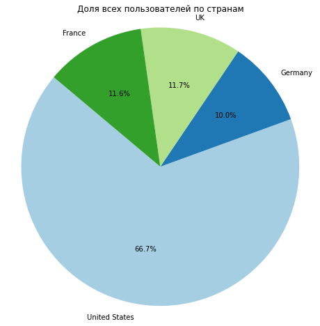

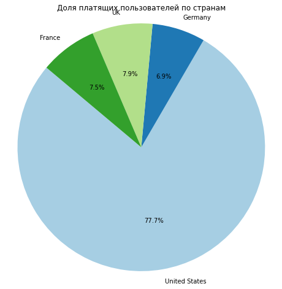

```python
plt.figure(figsize=(8, 8))
plt.pie(region_analysis['Общее количество пользователей'], labels=region_analysis['region'], autopct='%1.1f%%', startangle=140, colors=plt.cm.Paired(range(len(region_analysis))))
plt.title('Доля всех пользователей по странам')
plt.axis('equal')

plt.figure(figsize=(8, 8))
plt.pie(region_analysis['Платящие пользователи'], labels=region_analysis['region'], autopct='%1.1f%%', startangle=140, colors=plt.cm.Paired(range(len(region_analysis))))
plt.title('Доля платящих пользователей по странам')
plt.axis('equal')

plt.show()
```

> - Абсолютное большинство пользователей приходит из США - 100002 пользователя, затем идут такие страны, как Великобритания и Франция с небольшим отрывом: 17575 и 17450 соответственно, и меньше всего клиентов приходит из Германии - 14981.
> - С платящими пользователями такая же ситуация, больше всего платящих пользователей из США - 6902, у остальных стран пользователей меньше тысячи на страну.

### Анализ пользователей по устройствам

```python
device_analysis = performance_analysis(profiles, 'device')
device_analysis.style.format({
        'Доля платящих пользователей': '{:.2%}'
    })
```

|  | device | Общее количество пользователей | Платящие пользователи | Доля платящих пользователей |
| --- | --- | --- | --- | --- |
| 1 | Mac | 30042 | 1912 | 6.36% |
| 3 | iPhone | 54479 | 3382 | 6.21% |
| 0 | Android | 35032 | 2050 | 5.85% |
| 2 | PC | 30455 | 1537 | 5.05% |

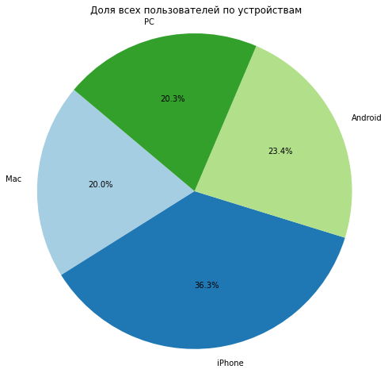

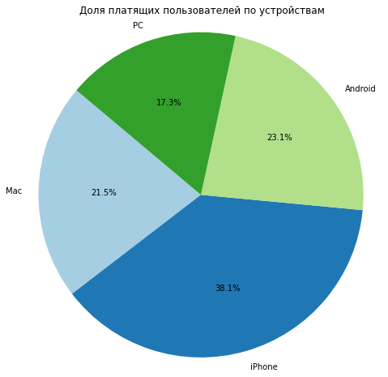

```python
plt.figure(figsize=(8, 8))
plt.pie(device_analysis['Общее количество пользователей'], labels=device_analysis['device'], autopct='%1.1f%%', startangle=140, colors=plt.cm.Paired(range(len(region_analysis))))
plt.title('Доля всех пользователей по устройствам')
plt.axis('equal')

plt.figure(figsize=(8, 8))
plt.pie(device_analysis['Платящие пользователи'], labels=device_analysis['device'], autopct='%1.1f%%', startangle=140, colors=plt.cm.Paired(range(len(region_analysis))))
plt.title('Доля платящих пользователей по устройствам')
plt.axis('equal')

plt.show()
```

> - Больше всего пользователей пользуются iphone - около 36.3%, затем идет android с 23.4% и MAC и PC c практически одинаковым результатом: 20.0% и 20.3% соответственно.
> - Большинство платящих пользователей пользуются iphone - 38.1%, затем идет android, MAC и PC с 23.1%, 21.5% и 17.3% соответственно.

### Анализ пользователей по каналам привлечения

```python
channel_analysis = performance_analysis(profiles, 'channel')
channel_analysis.style.format({
        'Доля платящих пользователей': '{:.2%}'
    })
```

|  | channel | Общее количество пользователей | Платящие пользователи | Доля платящих пользователей |
| --- | --- | --- | --- | --- |
| 1 | FaceBoom | 29144 | 3557 | 12.20% |
| 0 | AdNonSense | 3880 | 440 | 11.34% |
| 9 | lambdaMediaAds | 2149 | 225 | 10.47% |
| 6 | TipTop | 19561 | 1878 | 9.60% |
| 5 | RocketSuperAds | 4448 | 352 | 7.91% |
| 7 | WahooNetBanner | 8553 | 453 | 5.30% |
| 8 | YRabbit | 4312 | 165 | 3.83% |
| 3 | MediaTornado | 4364 | 156 | 3.57% |
| 2 | LeapBob | 8553 | 262 | 3.06% |
| 4 | OppleCreativeMedia | 8605 | 233 | 2.71% |
| 10 | organic | 56439 | 1160 | 2.06% |

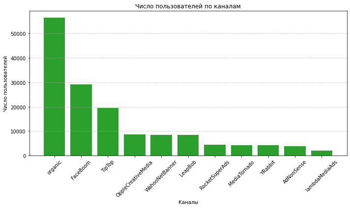

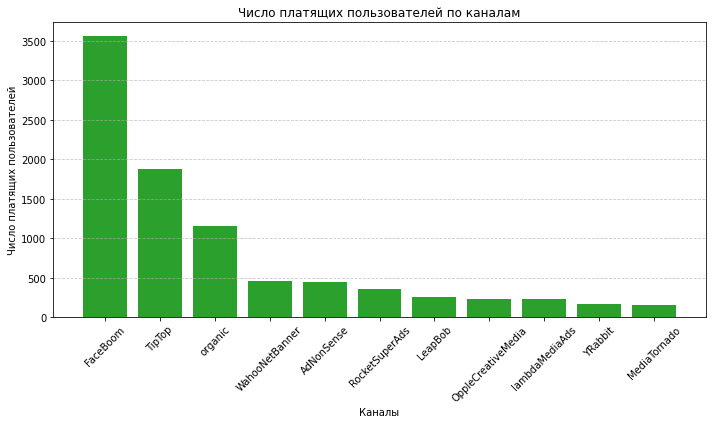

```python
channel_analysis_sorted = channel_analysis.sort_values('Общее количество пользователей', ascending=False)

plt.figure(figsize=(10, 6))
plt.bar(channel_analysis_sorted['channel'], channel_analysis_sorted['Общее количество пользователей'], color='tab:green')
plt.xlabel('Каналы')
plt.ylabel('Число пользователей')
plt.title('Число пользователей по каналам')
plt.xticks(rotation=45)  # Rotate labels to prevent overlap
plt.grid(axis='y', linestyle='--', alpha=0.7)  # Add horizontal grid lines for better readability
plt.tight_layout()  # Adjust layout to make room for label rotation

channel_analysis_sorted = channel_analysis.sort_values('Платящие пользователи', ascending=False)

plt.figure(figsize=(10, 6))
plt.bar(channel_analysis_sorted['channel'], channel_analysis_sorted['Платящие пользователи'], color='tab:green')
plt.xlabel('Каналы')
plt.ylabel('Число платящих пользователей')
plt.title('Число платящих пользователей по каналам')
plt.xticks(rotation=45)  # Rotate labels to prevent overlap
plt.grid(axis='y', linestyle='--', alpha=0.7)  # Add horizontal grid lines for better readability
plt.tight_layout()
plt.show()
```

> - Больше всего пользователей пришло естественным образом - 37,6%, также много пользователей пришло через FaceBoom - 19,4% и TipTop - 13.0% и так далее.
> - Если рассматривать платящих пользователей, то больше всего платящих пользователей пришло через канал FaceBoom - 40.1%, следующий канал - TipTop - 21.1%, естественные пользователи - 13.1%

### Мини итог

- Составлены профили пользователей и определены даты привлеения клиентов: Минимальная дата привлечения пользователей: **2019-05-01**, Максимальная дата привлечения пользователей: **2019-10-27**
- **Анализ пользователей по странам:**
  > - Абсолютное большинство пользователей приходит из США - 100002 пользователя, затем идут такие страны, как Великобритания и Франция с небольшим отрывом: 17575 и 17450 соответственно, и меньше всего клиентов приходит из Германии - 14981.
  > - С платящими пользователями такая же ситуация, больше всего платящих пользователей из США - 6902, у остальных стран пользователей меньше тысячи на страну.
- **Анализ пользователей по устройствам:**
  > - Больше всего пользователей пользуются iphone - около 36.3%, затем идет android с 23.4% и MAC и PC c практически одинаковым результатом: 20.0% и 20.3% соответственно.
  > - Юольшинство платящих пользователей пользуются iphone - 38.1%, затем идет android, MAC и PC с 23.1%, 21.5% и 17.3% соответственно.
- **Анализ пользователей по каналам привлечения:**
  > - Больше всего пользователей пришло естественным образом - 37,6%, также много пользователей пришло через FaceBoom - 19,4% и TipTop - 13.0% и так далее.
  > - Если рассматривать платящих пользователей, то больше всего платящих пользователей пришло через канал FaceBoom - 40.1%, следующий канал - TipTop - 21.1%, естественные пользователи - 13.1%

## Маркетинг

- Посчитайте общую сумму расходов на маркетинг.
- Выясните, как траты распределены по рекламным источникам, то есть сколько денег потратили на каждый источник.
- Постройте график с визуализацией динамики изменения расходов во времени по неделям по каждому источнику. Затем на другом графике визуализируйте динамику изменения расходов во времени по месяцам по каждому источнику.
- Узнайте, сколько в среднем стоило привлечение одного пользователя (CAC) из каждого источника. Используйте профили пользователей.

Напишите промежуточные выводы.

### Общие расходы на рекламу

```python
total_costs = costs['costs'].sum()
print(f'Общие расходы на рекламу: {round(total_costs, 2)} руб.')
```

```
Общие расходы на рекламу: 105497.3 руб.
```

### Распределение расходов на рекламу по каналам

```python
channel_costs = costs.groupby('channel')['costs'].sum().sort_values(ascending=False)
channel_costs = pd.DataFrame(channel_costs).rename({'costs': 'Расходы на рекламу'})
title = "Распределение расходов на рекламу по каналам"
print(f"\033[1m{title}\033[0m")
channel_costs
```

```
Распределение расходов на рекламу по каналам
```

| channel | costs |
| --- | --- |
| TipTop | 54751.30 |
| FaceBoom | 32445.60 |
| WahooNetBanner | 5151.00 |
| AdNonSense | 3911.25 |
| OppleCreativeMedia | 2151.25 |
| RocketSuperAds | 1833.00 |
| LeapBob | 1797.60 |
| lambdaMediaAds | 1557.60 |
| MediaTornado | 954.48 |
| YRabbit | 944.22 |

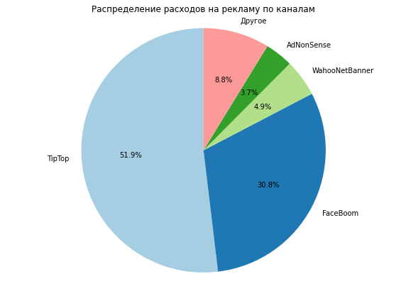

```python
# Определим все каналы с маленьким расходов в категорию "Другое"

channel_costs = costs.groupby('channel')['costs'].sum().sort_values(ascending=False)
total_costs = channel_costs.sum()
threshold = 0.03  # 3%
small_categories = channel_costs[channel_costs / total_costs < threshold]
channel_costs = channel_costs[channel_costs / total_costs >= threshold]
if not small_categories.empty:
    channel_costs['Другое'] = small_categories.sum()

# Создание круговой диаграммы
plt.figure(figsize=(10, 7))
plt.pie(channel_costs, labels=channel_costs.index, autopct='%1.1f%%', startangle=90, colors=plt.cm.Paired(range(len(channel_costs))))
plt.title('Распределение расходов на рекламу по каналам')
plt.axis('equal')  # Equal aspect ratio ensures that pie is drawn as a circle
plt.show()
```

> - Больше половины расходов на рекламу приходится на канал Tiptop - 51.9%, далее идет канал FaceBoom - 30.8%, и тд.

### Динамика расходов на рекламу по неделям и по месяцам

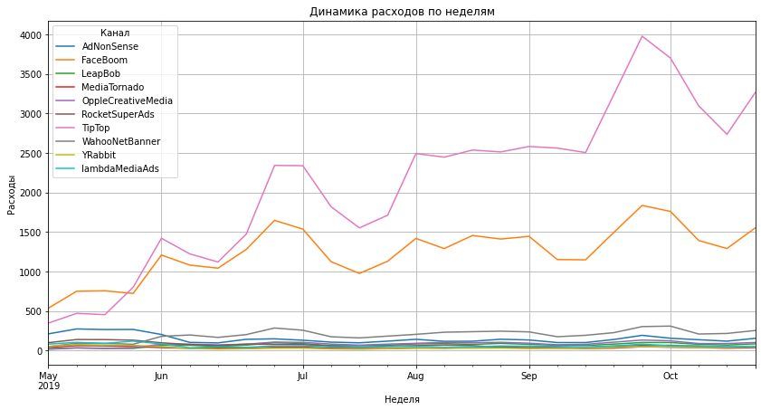

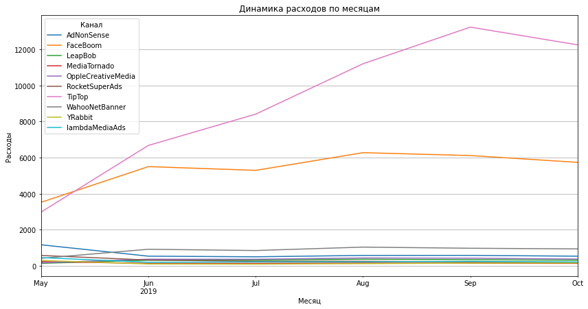

```python
costs['dt'] = pd.to_datetime(costs['dt'])

# Группировка данных по неделям
weekly_costs = costs.groupby([costs['dt'].dt.to_period('W'), 'channel'])['costs'].sum().unstack(fill_value=0)
# Группировка данных по месяцам
monthly_costs = costs.groupby([costs['dt'].dt.to_period('M'), 'channel'])['costs'].sum().unstack(fill_value=0)

# График по неделям
weekly_costs.plot(figsize=(14, 7), title='Динамика расходов по неделям', grid=True)
plt.xlabel('Неделя')
plt.ylabel('Расходы')
plt.legend(title='Канал')
plt.show()

# График по месяцам
monthly_costs.plot(figsize=(14, 7), title='Динамика расходов по месяцам', grid=True)
plt.xlabel('Месяц')
plt.ylabel('Расходы')
plt.legend(title='Канал')
plt.show()
```

> - Для обоих графиков наблюдается похожий тренд: за последние полгода, расходы на канал **TipTop** превысили расходы на **FaceBoom** в **два раза**. В середине сентября расходы на оба канала сильно выросли, однако потом упали, но снова начали расти с середины октября.

### Средняя стоимость привлечения одного пользователя(САС)

```python
ltv_raw, ltv, ltv_history, roi, roi_history = get_ltv(profiles,
                                                      orders,
                                                      observation_date,
                                                      7,
                                                      dimensions=['channel'])

cac_channel = pd.DataFrame(roi['cac'].sort_values(ascending=False))
title = "Средняя стоимость пользователя по каналам"
print(f"\033[1m{title}\033[0m")
cac_channel
```

```
Средняя стоимость пользователя по каналам
```

| channel | cac |
| --- | --- |
| TipTop | 2.793219 |
| FaceBoom | 1.113191 |
| AdNonSense | 1.007945 |
| lambdaMediaAds | 0.725634 |
| WahooNetBanner | 0.602050 |
| RocketSuperAds | 0.413081 |
| OppleCreativeMedia | 0.249941 |
| MediaTornado | 0.218724 |
| YRabbit | 0.218639 |
| LeapBob | 0.210099 |

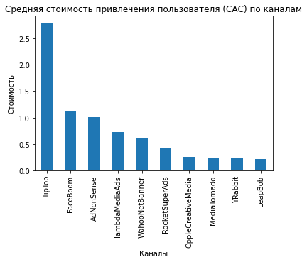

```python
roi['cac'].sort_values(ascending=False).plot(kind='bar',
                                             title='Средняя стоимость привлечения пользователя (САС) по каналам',
                                             xlabel='Каналы',
                                             ylabel='Стоимость');
```

> Самая высокая средняя стоимость привлечения(САС) наблюдается у канала **TipTop**, что превышает стоимость примерно в 2,5 раза. Нужно обратить внимание на этот канал.

### Мини итог

- Общие расходы на рекламу: **105497.3 руб.**
- Больше половины расходов на рекламу приходится на канал **Tiptop - 51.9%**, далее идет канал **FaceBoom - 30.8%**, и тд.
- Для обоих графиков наблюдается похожий тренд: за последние полгода, расходы на канал **TipTop** превысили расходы на **FaceBoom** в **два раза**. В середине сентября расходы на оба канала сильно выросли, однако потом упали, но снова начали расти с середины октября.
- Самая высокая средняя стоимость привлечения(САС) наблюдается у канала **TipTop**, что **превышает стоимость примерно в 2,5 раза.** Нужно обратить внимание на этот канал.

## Оцените окупаемость рекламы

Используя графики LTV, ROI и CAC, проанализируйте окупаемость рекламы. Считайте, что на календаре 1 ноября 2019 года, а в бизнес-плане заложено, что пользователи должны окупаться не позднее чем через две недели после привлечения. Необходимость включения в анализ органических пользователей определите самостоятельно.

- Проанализируйте окупаемость рекламы c помощью графиков LTV и ROI, а также графики динамики LTV, CAC и ROI.
- Проверьте конверсию пользователей и динамику её изменения. То же самое сделайте с удержанием пользователей. Постройте и изучите графики конверсии и удержания.
- Проанализируйте окупаемость рекламы с разбивкой по устройствам. Постройте графики LTV и ROI, а также графики динамики LTV, CAC и ROI.
- Проанализируйте окупаемость рекламы с разбивкой по странам. Постройте графики LTV и ROI, а также графики динамики LTV, CAC и ROI.
- Проанализируйте окупаемость рекламы с разбивкой по рекламным каналам. Постройте графики LTV и ROI, а также графики динамики LTV, CAC и ROI.
- Ответьте на такие вопросы:
  - Окупается ли реклама, направленная на привлечение пользователей в целом?
  - Какие устройства, страны и рекламные каналы могут оказывать негативное влияние на окупаемость рекламы?
  - Чем могут быть вызваны проблемы окупаемости?

Напишите вывод, опишите возможные причины обнаруженных проблем и промежуточные рекомендации для рекламного отдела.

```python
# Перед анализом удалим пользователей, которые пришли самостоятельно(organic)
visits = visits[visits['channel'] != 'organic']
costs = costs[costs['channel'] != 'organic']
profiles = profiles[profiles['channel'] != 'organic']
```

### Графики LTV, ROI и САС

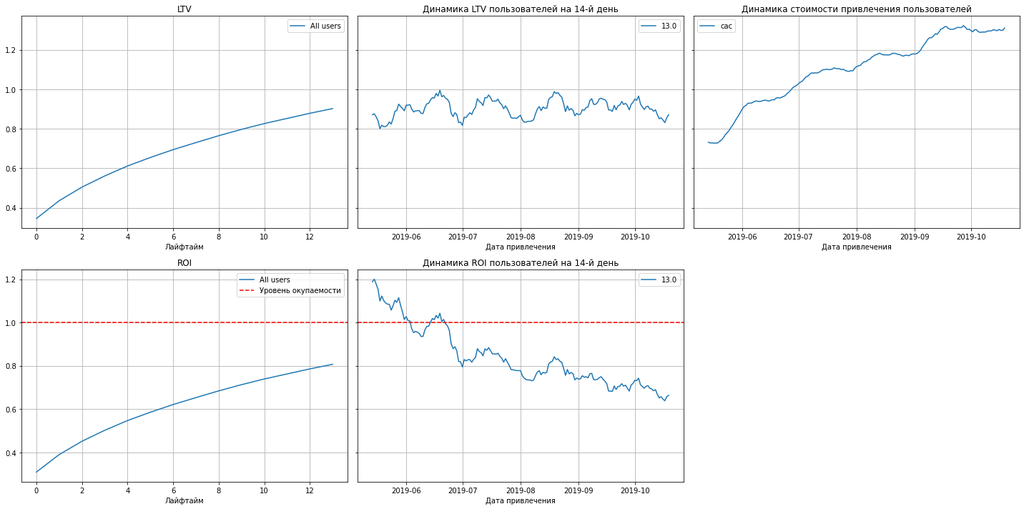

```python
ltv_raw_dev, ltv_dev, ltv_history_dev, roi_dev, roi_history_dev = get_ltv(profiles,
        orders,
        observation_date,
        analysis_horizon
       )

plot_ltv_roi(ltv_dev,
             ltv_history_dev,
             roi_dev,
             roi_history_dev,
             analysis_horizon,
             window=14)
```

> **Реклама не окупается, ROI ниже единицы.** **Проблемы с окупаемостью возникли в июне**, тогда реклама перестала окупаться. Также за последнее время сильно выросла цена пользователя САС. **Динамика LTV в целом стабильна.**